# Regression + Factor analysis: What affects math performance?

by JUMEX365

## Data and packages

```r
library(foreign)
library(dplyr)
library(ggplot2)
library(psych)
fulldata <- read.spss("asgrusb7.sav", to.data.frame = T, use.value.labels = T)
```

## Linear Regression_Part1

## Data for regression

```r
darreg <- fulldata[c("ASMMAT01", "ASBGSSB", "ASBGSCM", "ITSEX", "ASDAGE")]

darreg$ASMMAT01 = as.numeric(as.character(darreg$ASMMAT01))
darreg$ASBGSSB= as.numeric(as.character(darreg$ASBGSSB))
darreg$ASBGSCM= as.numeric(as.character(darreg$ASBGSCM))
darreg$ASDAGE= as.numeric(as.character(darreg$ASDAGE))

darreg <- na.omit(darreg)
```

## Descriptive Statistics

### Dependent variable

ASMMAT01 - achievement in math

```r
describe(darreg$ASMMAT01)
```

```
##    vars    n   mean    sd median trimmed  mad    min    max  range  skew
## X1    1 2108 558.74 67.26 559.77   559.8 69.6 337.32 779.59 442.27 -0.12
##    kurtosis   se
## X1    -0.11 1.46
```

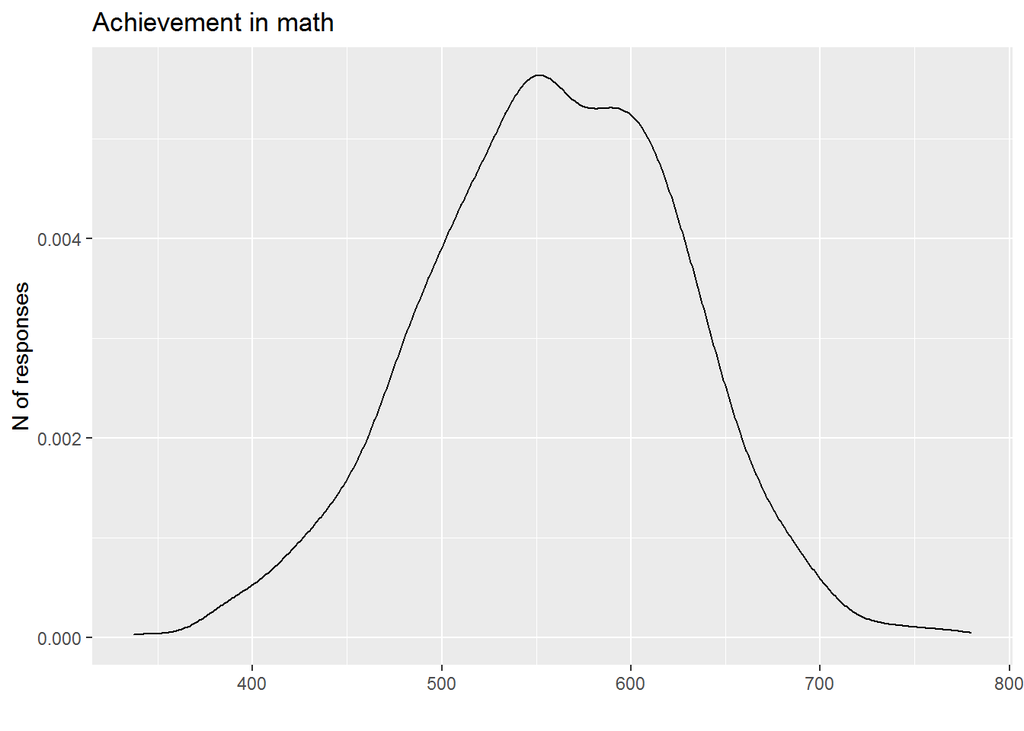

```r
ggplot(darreg, aes(x = ASMMAT01))+geom_density()+ggtitle("Achievement in math")+xlab("")+
  ylab("N of responses")
```

### Independent variables

ASBGSSB - student’s sense of belonging to school

```r
describe(darreg$ASBGSSB)
```

```
##    vars    n mean   sd median trimmed mad  min   max range skew kurtosis   se
## X1    1 2108 9.31 1.89   9.02    9.27 1.9 3.14 12.75  9.61 0.15    -0.01 0.04
```

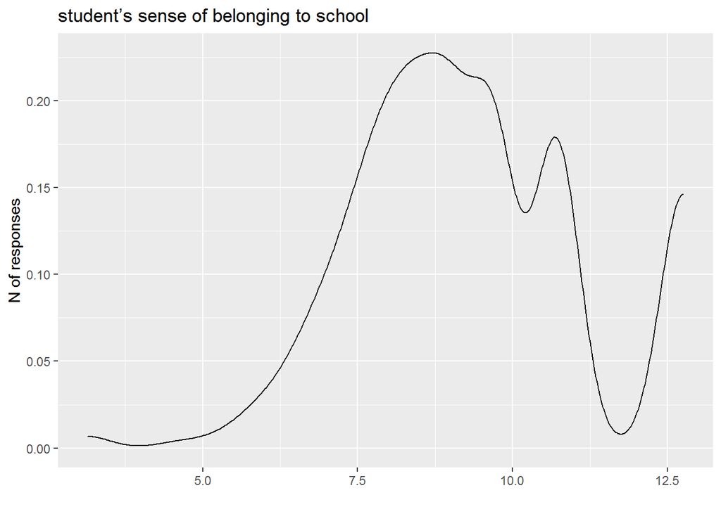

```r
ggplot(darreg, aes(x = ASBGSSB))+geom_density()+ggtitle("student’s sense of belonging to school")+xlab("")+
  ylab("N of responses")
```

ASBGSCM - student’s confidence in mathematics

```r
describe(darreg$ASBGSCM)
```

```
##    vars    n mean   sd median trimmed  mad min   max range skew kurtosis   se
## X1    1 2108 9.57 1.93   9.23    9.44 1.65 2.8 14.41 11.61 0.54     0.73 0.04
```

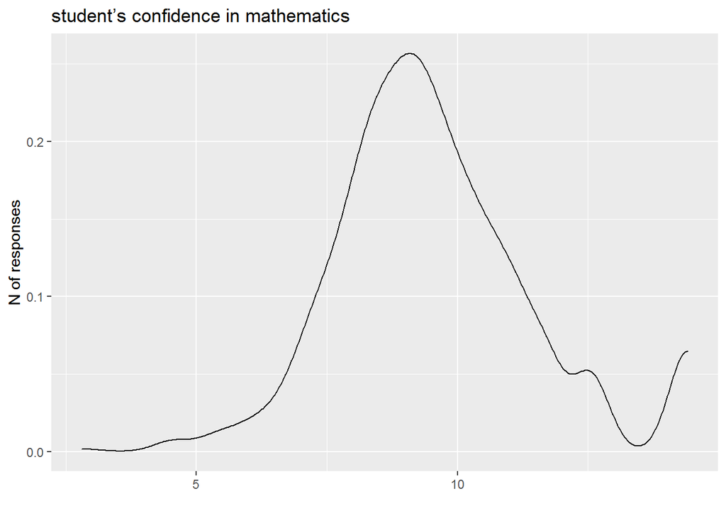

```r
ggplot(darreg, aes(x = ASBGSCM))+geom_density()+ggtitle("student’s confidence in mathematics")+xlab("")+
  ylab("N of responses")
```

### Control variables

ASDAGE - age

```r
describe(darreg$ASDAGE)
```

```
##    vars    n  mean   sd median trimmed  mad  min   max range skew kurtosis   se
## X1    1 2108 10.84 0.39  10.83   10.83 0.37 9.75 13.08  3.33 0.71      2.1 0.01
```

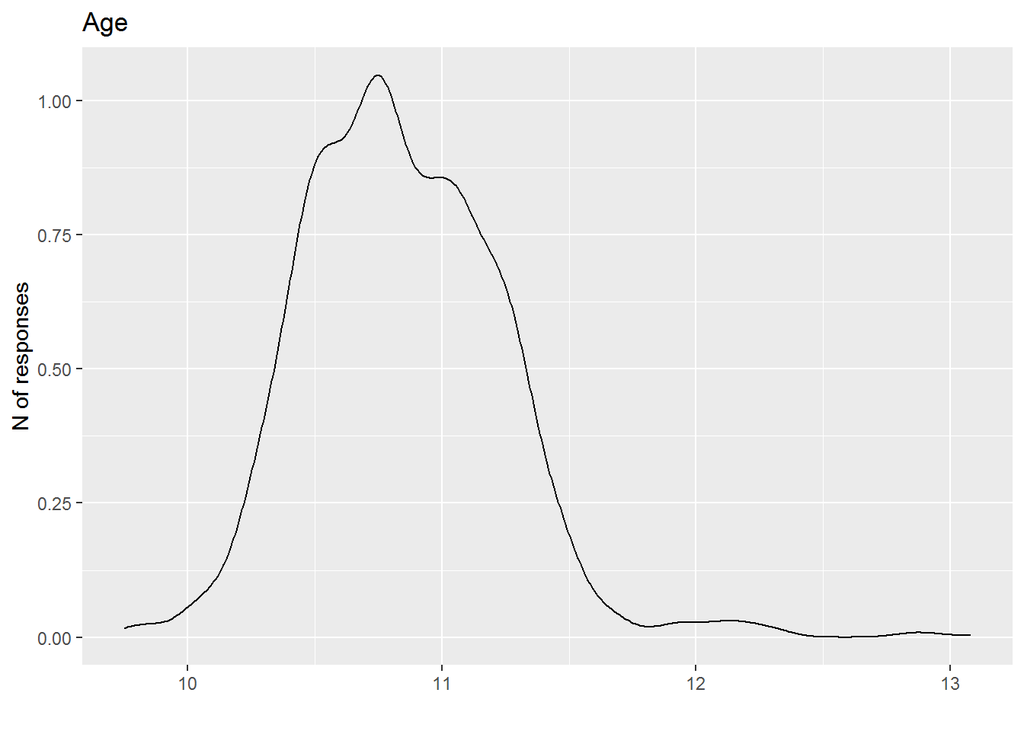

```r
ggplot(darreg, aes(x = ASDAGE))+geom_density()+ggtitle("Age")+xlab("")+
  ylab("N of responses")
```

ITSEX - sex

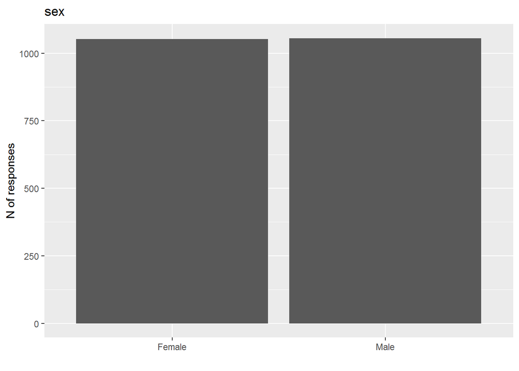

```r
ggplot(darreg, aes(x = ITSEX))+geom_bar()+ggtitle("sex")+xlab("")+
  ylab("N of responses")
```

## Model

```r
model1 = lm(data = darreg, ASMMAT01 ~ ASBGSSB + ASBGSCM + ITSEX + ASDAGE)
summary(model1)
```

```
##
## Call:
## lm(formula = ASMMAT01 ~ ASBGSSB + ASBGSCM + ITSEX + ASDAGE, data = darreg)
##
## Residuals:
##      Min       1Q   Median       3Q      Max
## -199.053  -40.504    0.629   41.383  222.212
##
## Coefficients:
##             Estimate Std. Error t value Pr(>|t|)
## (Intercept) 470.1989    38.5409  12.200  < 2e-16 ***
## ASBGSSB      -2.4419     0.7243  -3.371 0.000762 ***
## ASBGSCM      15.2387     0.7052  21.608  < 2e-16 ***
## ITSEXMale    -8.9328     2.6905  -3.320 0.000915 ***
## ASDAGE       -2.7760     3.4059  -0.815 0.415132
## ---
## Signif. codes:  0 '***' 0.001 '**' 0.01 '*' 0.05 '.' 0.1 ' ' 1
##
## Residual standard error: 60.8 on 2103 degrees of freedom
## Multiple R-squared:  0.1845, Adjusted R-squared:  0.1829
## F-statistic: 118.9 on 4 and 2103 DF,  p-value: < 2.2e-16
```

- ASBGSSB - Significant. increase in student’s sense of belonging to school (by +1) decrease math achievement by -2.4
- ASBGSCM - Significant. increase in student’s confidence in mathematics (by+1) rise math achievement by 15.2
- ITSEX - Significant. For males rise math achievement is lower by -8.9 than for females.
- ASDAGE - Not significant.

## FA_Part2

### Data editing

```r
efadat <- fulldata[c("ASBG11A", "ASBG11B", "ASBG11C", "ASBG11D", "ASBG11E", "ASBG11F", "ASBG11G", "ASBG11H", "ASBG11I", "ASBG11J", "ASBG11K")]
efadat_1 <- na.omit(efadat)

cols.num <- c("ASBG11A", "ASBG11B", "ASBG11C", "ASBG11D", "ASBG11E", "ASBG11F", "ASBG11G", "ASBG11H", "ASBG11I", "ASBG11J", "ASBG11K")
sapply(efadat_1, class)
```

```
##  ASBG11A  ASBG11B  ASBG11C  ASBG11D  ASBG11E  ASBG11F  ASBG11G  ASBG11H
## "factor" "factor" "factor" "factor" "factor" "factor" "factor" "factor"
##  ASBG11I  ASBG11J  ASBG11K
## "factor" "factor" "factor"
```

```r
efadat_1[cols.num] <- sapply(efadat_1[cols.num], as.numeric)
```

### Tests

```r
library(sjPlot)
tab_corr(efadat_1, corr.method = "spearman")
```

|  | ASBG11A | ASBG11B | ASBG11C | ASBG11D | ASBG11E | ASBG11F | ASBG11G | ASBG11H | ASBG11I | ASBG11J | ASBG11K |
| --- | --- | --- | --- | --- | --- | --- | --- | --- | --- | --- | --- |
| ASBG11A |  | 0.301*** | 0.487*** | 0.245*** | 0.337*** | 0.524*** | 0.311*** | 0.312*** | 0.238*** | 0.178*** | 0.374*** |
| ASBG11B | 0.301*** |  | 0.331*** | 0.183*** | 0.184*** | 0.294*** | 0.226*** | 0.202*** | 0.171*** | 0.144*** | 0.207*** |
| ASBG11C | 0.487*** | 0.331*** |  | 0.306*** | 0.364*** | 0.462*** | 0.338*** | 0.319*** | 0.275*** | 0.220*** | 0.369*** |
| ASBG11D | 0.245*** | 0.183*** | 0.306*** |  | 0.341*** | 0.243*** | 0.248*** | 0.240*** | 0.207*** | 0.159*** | 0.263*** |
| ASBG11E | 0.337*** | 0.184*** | 0.364*** | 0.341*** |  | 0.361*** | 0.309*** | 0.281*** | 0.264*** | 0.200*** | 0.346*** |
| ASBG11F | 0.524*** | 0.294*** | 0.462*** | 0.243*** | 0.361*** |  | 0.355*** | 0.285*** | 0.218*** | 0.206*** | 0.414*** |
| ASBG11G | 0.311*** | 0.226*** | 0.338*** | 0.248*** | 0.309*** | 0.355*** |  | 0.327*** | 0.268*** | 0.243*** | 0.363*** |
| ASBG11H | 0.312*** | 0.202*** | 0.319*** | 0.240*** | 0.281*** | 0.285*** | 0.327*** |  | 0.384*** | 0.240*** | 0.315*** |
| ASBG11I | 0.238*** | 0.171*** | 0.275*** | 0.207*** | 0.264*** | 0.218*** | 0.268*** | 0.384*** |  | 0.358*** | 0.293*** |
| ASBG11J | 0.178*** | 0.144*** | 0.220*** | 0.159*** | 0.200*** | 0.206*** | 0.243*** | 0.240*** | 0.358*** |  | 0.198*** |
| ASBG11K | 0.374*** | 0.207*** | 0.369*** | 0.263*** | 0.346*** | 0.414*** | 0.363*** | 0.315*** | 0.293*** | 0.198*** |  |
| Computed correlation used spearman-method with listwise-deletion. |  |  |  |  |  |  |  |  |  |  |  |

All correlations are significant

```r
library(psych)
KMO(efadat_1)
```

```
## Kaiser-Meyer-Olkin factor adequacy
## Call: KMO(r = efadat_1)
## Overall MSA =  0.9
## MSA for each item =
## ASBG11A ASBG11B ASBG11C ASBG11D ASBG11E ASBG11F ASBG11G ASBG11H ASBG11I ASBG11J
##    0.87    0.93    0.90    0.90    0.91    0.88    0.93    0.91    0.84    0.86
## ASBG11K
##    0.93
```

MSA = 0.9 - good sign.

### Choice of factors

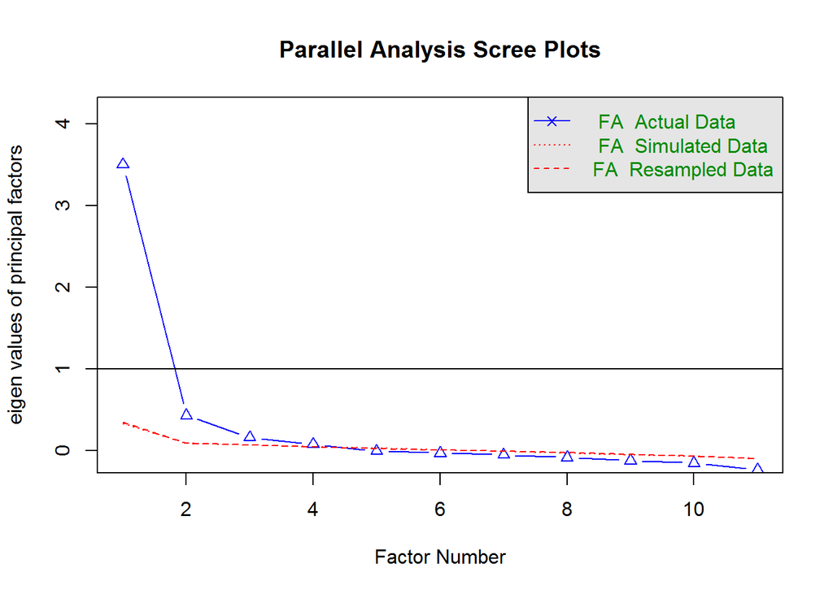

```
## Parallel analysis suggests that the number of factors =  4  and the number of components =  NA
```

```r
fa.parallel(efadat_1, fa="fa", n.iter=100)
```

### FA

```r
fa(efadat_1, nfactors=1, rotate="none", fm="ml")
```

```
## Factor Analysis using method =  ml
## Call: fa(r = efadat_1, nfactors = 1, rotate = "none", fm = "ml")
## Standardized loadings (pattern matrix) based upon correlation matrix
##          ML1   h2   u2 com
## ASBG11A 0.64 0.41 0.59   1
## ASBG11B 0.41 0.17 0.83   1
## ASBG11C 0.66 0.43 0.57   1
## ASBG11D 0.48 0.23 0.77   1
## ASBG11E 0.58 0.34 0.66   1
## ASBG11F 0.68 0.47 0.53   1
## ASBG11G 0.58 0.34 0.66   1
## ASBG11H 0.57 0.33 0.67   1
## ASBG11I 0.48 0.23 0.77   1
## ASBG11J 0.40 0.16 0.84   1
## ASBG11K 0.62 0.39 0.61   1
##
##                 ML1
## SS loadings    3.50
## Proportion Var 0.32
##
## Mean item complexity =  1
## Test of the hypothesis that 1 factor is sufficient.
##
## The degrees of freedom for the null model are  55  and the objective function was  2.77 with Chi Square of  5637.04
## The degrees of freedom for the model are 44  and the objective function was  0.3
##
## The root mean square of the residuals (RMSR) is  0.05
## The df corrected root mean square of the residuals is  0.06
##
## The harmonic number of observations is  2042 with the empirical chi square  670.52  with prob <  5.6e-113
## The total number of observations was  2042  with Likelihood Chi Square =  618.69  with prob <  1.9e-102
##
## Tucker Lewis Index of factoring reliability =  0.871
## RMSEA index =  0.08  and the 90 % confidence intervals are  0.074 0.086
## BIC =  283.34
## Fit based upon off diagonal values = 0.97
## Measures of factor score adequacy
##                                                    ML1
## Correlation of (regression) scores with factors   0.92
## Multiple R square of scores with factors          0.85
## Minimum correlation of possible factor scores     0.69
```

- 1 factor no rotation is needed.
- RMSR = 0.05. oK.
- Tucker-Lewis Index = 0.871 (<0.95). Result under threshold. Not good.
- RMSEA = 0.08 (~ 0.08). Result almost equal to threshold. Ok.
- Var = 0.32 moderate result.

Factor1: ASBG11A - laughed at me ASBG11B - drop me from games ASBG11C - lied about me ASBG11D - stole my staff ASBG11E - damaging my staff ASBG11F - hurt  
ASBG11G - forced ASBG11H - sent unpleasant messages ASBG11I - posted things ASBG11J - posted photos ASBG11K - threatened

Overall it can be described as bullying.

## Fa + model

```r
library(lavaan)
bulm <- '
bullying =~ ASBG11A + ASBG11B + ASBG11C + ASBG11D + ASBG11E + ASBG11F + ASBG11G + ASBG11H + ASBG11I + ASBG11J + ASBG11K
'
mod_bul_1 = cfa(bulm, data = efadat_1)
```

### Join not equal datasets

```r
library(lavaan)
set.seed(747474)
darreg <- darreg %>% sample_n (2042, replace = FALSE)
darreg <- na.omit(darreg)
darreg[6] <- lavPredict(mod_bul_1, method = "regression")
colnames(darreg)[6] <- c("bullying")
```

### Model

```r
model_fin <- lm(data = darreg, ASMMAT01 ~ ASBGSSB + ASBGSCM + ITSEX + ASDAGE + bullying)
summary(model_fin)
```

```
##
## Call:
## lm(formula = ASMMAT01 ~ ASBGSSB + ASBGSCM + ITSEX + ASDAGE +
##     bullying, data = darreg)
##
## Residuals:
##      Min       1Q   Median       3Q      Max
## -197.699  -40.703    0.525   41.696  221.757
##
## Coefficients:
##             Estimate Std. Error t value Pr(>|t|)
## (Intercept) 460.0478    39.4412  11.664  < 2e-16 ***
## ASBGSSB      -2.3351     0.7356  -3.174 0.001523 **
## ASBGSCM      15.0870     0.7144  21.118  < 2e-16 ***
## ITSEXMale    -9.0385     2.7285  -3.313 0.000941 ***
## ASDAGE       -1.7803     3.4885  -0.510 0.609867
## bullying      0.8677     1.9531   0.444 0.656889
## ---
## Signif. codes:  0 '***' 0.001 '**' 0.01 '*' 0.05 '.' 0.1 ' ' 1
##
## Residual standard error: 60.76 on 2036 degrees of freedom
## Multiple R-squared:  0.1822, Adjusted R-squared:  0.1802
## F-statistic: 90.75 on 5 and 2036 DF,  p-value: < 2.2e-16
```

- Bullying is not significant thus attitudes have stronger effect on math achievement.